# Homework3

Safiya Alavi

10/18/2022

### Question 1

##### Split the data, stratifying on the outcome variable, survived. You should choose the proportions to split the data into. Verify that the training and testing data sets have the appropriate number of observations. Take a look at the training data and note any potential issues, such as missing data.

##### Why is it a good idea to use stratified sampling for this data?

The predictor variables age and cabin have missing values. Many of the cabin variables are missing, so it will be difficult to use this data for analysis. Just looking at the data, I see that for many observations where the fare is a higher number, there is a cabin specified. Although, for many observations with a lower value for fair, there is no cabin number. Without background information, this observation of the data may or may not have any meaning.

It is a good idea to use stratified sampling because we want to ensure we have a good representation of our total population who both survived and did not survive for our training and testing data.

```r
# split the titanic data into training and testing data sets
set.seed(12345)
titanic$pclass <- factor(titanic$pclass, levels = c(1,2,3))
titanic$survived <- factor(titanic$survived, levels = c("Yes","No"))
titanic_split <- initial_split(titanic, prop = 0.75, strata = survived)
titanic_training <- training(titanic_split)
titanic_testing <- testing(titanic_split)
```

### Question 2

##### Using the training data set, explore/describe the distribution of the outcome variable survived.

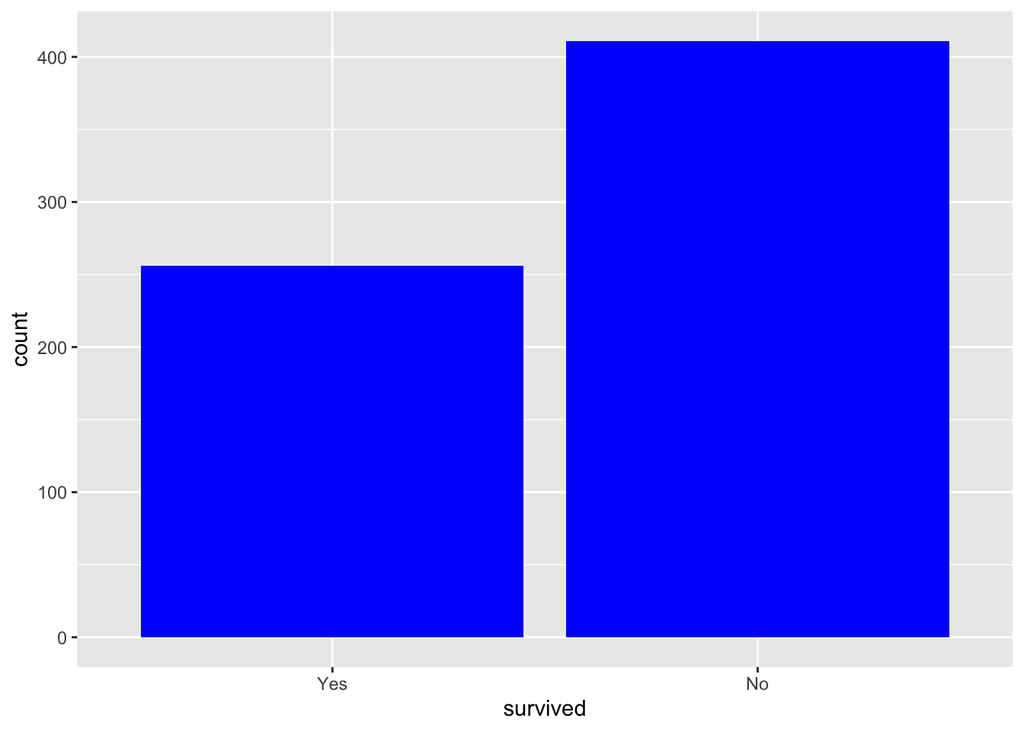

```r
titanic_training %>% ggplot(aes(x = survived)) + geom_bar(fill = "blue")
```

As we can see, the count for “No” in the survived column is a little more than 400, whereas the count for “Yes” is around 250.

### Question 3

##### Using the training data set, create a correlation matrix of all continuous variables. Create a visualization of the matrix, and describe any patterns you see. Are any predictors correlated with each other? Which ones, and in which direction?

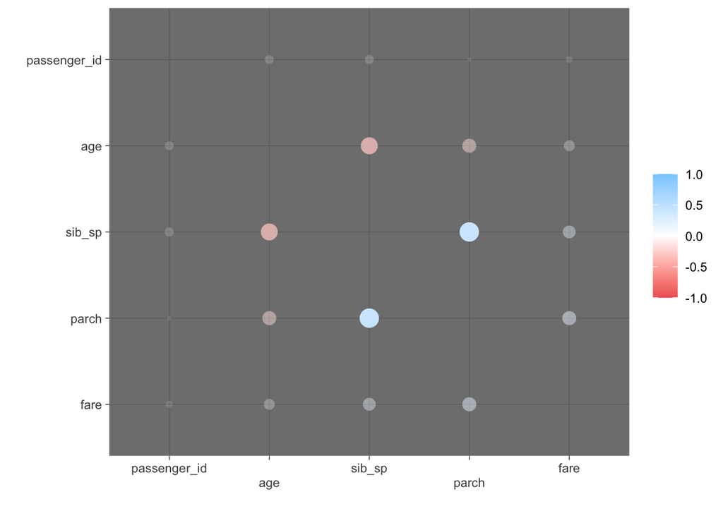

```r
cor_training_titanic <- titanic_training %>% select(passenger_id, age, sib_sp, parch, fare) %>% correlate()

rplot(cor_training_titanic) + theme_dark() + scale_x_discrete(guide = guide_axis(n.dodge=2))
```

Through the visual, we can see that age and sib_sp (# of siblings/spouses on board) are fairly correlated in the negative direction. Sib_sp and parch are also fairly correlated in the positive direction.

### Question 4

##### Using the training data, create a recipe predicting the outcome variable survived. Include the following predictors: ticket class, sex, age, number of siblings or spouses aboard, number of parents or children aboard, and passenger fare.

##### Recall that there were missing values for age. To deal with this, add an imputation step using step_impute_linear(). Next, use step_dummy() to dummy encode categorical predictors. Finally, include interactions between: Sex and passenger fare, and Age and passenger fare.

```r
titanic_recipe <- recipe(survived ~ pclass + sex + age + sib_sp + parch + fare, data = titanic_training) %>% step_impute_linear(age, impute_with = imp_vars(sib_sp)) %>% step_dummy(all_nominal_predictors()) %>% step_interact( ~ starts_with("sex"):fare + age:fare)
```

### Question 5

##### Specify a logistic regression model for classification using the “glm” engine. Then create a workflow. Add your model and the appropriate recipe. Finally, use fit() to apply your workflow to the training data.

```r
# specifying the logistic regression model using the glm engine
log_reg <- logistic_reg() %>% set_engine("glm") %>% set_mode("classification")

# creating a workflow
log_wkflow <- workflow() %>%
  add_model(log_reg) %>%
  add_recipe(titanic_recipe)

log_fit_titanic <- fit(log_wkflow, titanic_training)
```

### Question 6

##### Repeat Question 5, but this time specify a linear discriminant analysis model for classification using the “MASS” engine.

```r
# specifying the linear discriminant analysis model using the mass engine
lda_mod <- discrim_linear() %>% set_mode("classification") %>% set_engine("MASS")

lda_wkflow <- workflow() %>%
  add_model(lda_mod) %>%
  add_recipe(titanic_recipe)

lda_fit_titanic <- fit(lda_wkflow, titanic_training)
```

### Question 7

##### Repeat Question 5, but this time specify a quadratic discriminant analysis model for classification using the “MASS” engine.

```r
# specifying the quadratic discriminant analysis model using the mass engine
qda_mod <- discrim_quad() %>%
  set_mode("classification") %>%
  set_engine("MASS")

qda_wkflow <- workflow() %>%
  add_model(qda_mod) %>%
  add_recipe(titanic_recipe)

qda_fit_titanic <- fit(qda_wkflow, titanic_training)
```

### Question 8

```r
# specifying the naive Bayes model using the mass engine
nb_mod <- naive_Bayes() %>%
  set_mode("classification") %>%
  set_engine("klaR") %>%
  set_args(usekernel = FALSE)

nb_wkflow <- workflow() %>%
  add_model(nb_mod) %>%
  add_recipe(titanic_recipe)

nb_fit_titanic <- fit(nb_wkflow, titanic_training)
```

### Question 9

##### Now you’ve fit four different models to your training data.

##### Use predict() and bind_cols() to generate predictions using each of these 4 models and your training data. Then use the accuracy metric to assess the performance of each of the four models.

##### Which model achieved the highest accuracy on the training data?

```r
# logistic regression model
titanic_train_predict_log <- predict(log_fit_titanic, new_data = titanic_training %>% select(-survived), type = "class")

titanic_train_predict_log <- bind_cols(titanic_train_predict_log, titanic_training %>% select(survived))

log_acc_titantic <- augment(log_fit_titanic, new_data = titanic_training) %>% accuracy(truth = survived, estimate = .pred_class)

log_acc_titantic
```

```
## # A tibble: 1 × 3
##   .metric  .estimator .estimate
##   <chr>    <chr>          <dbl>
## 1 accuracy binary         0.813
```

```r
# Coburn's code

#log_acc_titantic <- predict(log_fit_titanic, new_data = titanic_training, type = "class") %>%  bind_cols(titanic_training %>% select(survived)) %>% accuracy(truth = survived, estimate = .pred_class)

#log_acc_titantic

# linear discriminant model
titanic_train_predict_lda <- predict(lda_fit_titanic, new_data = titanic_training %>% select(-survived), type = "prob")

titanic_train_predict_lda <- bind_cols(titanic_train_predict_lda, titanic_training %>% select(survived))

lda_acc_titantic <- augment(lda_fit_titanic, new_data = titanic_training) %>% accuracy(truth = survived, estimate = .pred_class)

lda_acc_titantic
```

```
## # A tibble: 1 × 3
##   .metric  .estimator .estimate
##   <chr>    <chr>          <dbl>
## 1 accuracy binary         0.793
```

```r
# quadratic discriminant model
titanic_train_predict_qda <- predict(qda_fit_titanic, new_data = titanic_training %>% select(-survived), type = "prob")

titanic_train_predict_qda <- bind_cols(titanic_train_predict_qda, titanic_training %>% select(survived))

qda_acc_titantic <- augment(qda_fit_titanic, new_data = titanic_training) %>% accuracy(truth = survived, estimate = .pred_class)

qda_acc_titantic
```

```
## # A tibble: 1 × 3
##   .metric  .estimator .estimate
##   <chr>    <chr>          <dbl>
## 1 accuracy binary         0.769
```

```r
# naive Bayes model
titanic_train_predict_nb <- predict(nb_fit_titanic, new_data = titanic_training %>% select(-survived), type = "prob")

titanic_train_predict_nb <- bind_cols(titanic_train_predict_nb, titanic_training %>% select(survived))

nb_acc_titantic <- augment(nb_fit_titanic, new_data = titanic_training) %>% accuracy(truth = survived, estimate = .pred_class)

nb_acc_titantic
```

```
## # A tibble: 1 × 3
##   .metric  .estimator .estimate
##   <chr>    <chr>          <dbl>
## 1 accuracy binary         0.771
```

```r
results <- bind_rows(log_acc_titantic, lda_acc_titantic, qda_acc_titantic, nb_acc_titantic) %>%
  tibble() %>% mutate(model = c("Logistic Regression Model", "Linear Discriminant Model", "Quadratic Discriminant Model", "Naive Bayes Model")) %>%
  select(model, .estimate) %>% arrange(.estimate)
results
```

```
## # A tibble: 4 × 2
##   model                        .estimate
##   <chr>                            <dbl>
## 1 Quadratic Discriminant Model     0.769
## 2 Naive Bayes Model                0.771
## 3 Linear Discriminant Model        0.793
## 4 Logistic Regression Model        0.813
```

### Question 10

##### Fit the model with the highest training accuracy to the testing data. Report the accuracy of the model on the testing data.

##### Again using the testing data, create a confusion matrix and visualize it. Plot an ROC curve and calculate the area under it (AUC).

##### How did the model perform? Compare its training and testing accuracies. If the values differ, why do you think this is so?

```r
# logistic regression model with testing data
titanic_test_predict_log <- predict(log_fit_titanic, new_data = titanic_testing %>% select(-survived), type = "prob")

titanic_test_predict_log <- bind_cols(titanic_test_predict_log, titanic_testing %>% select(survived))

log_acc_titantic_test <- augment(log_fit_titanic, new_data = titanic_testing) %>% accuracy(truth = survived, estimate = .pred_class)

log_acc_titantic_test #79.9% accuracy
```

```
## # A tibble: 1 × 3
##   .metric  .estimator .estimate
##   <chr>    <chr>          <dbl>
## 1 accuracy binary         0.799
```

The highest training accuracy came from the logistic regression model, and the estimate for the accuracy on the testing data is 79.9%.

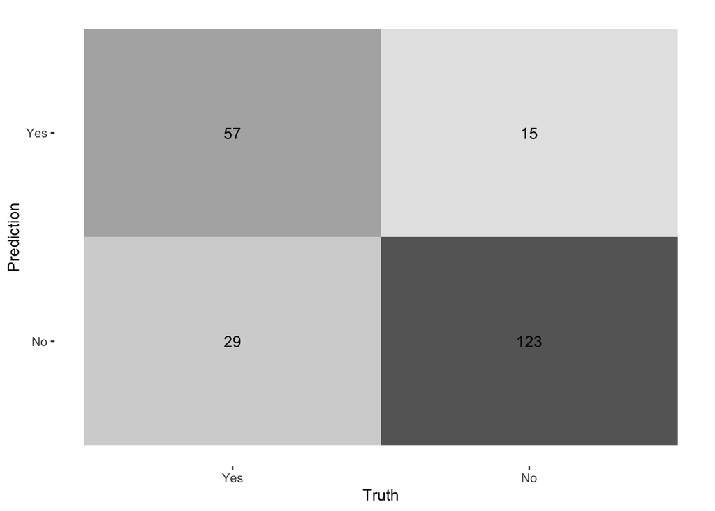

```r
titanic_log_test <- fit(log_wkflow, titanic_testing)
titanic_log_test_results <- augment(titanic_log_test, new_data = titanic_testing)

titanic_log_test_results %>% conf_mat(truth = survived, estimate = .pred_class) %>% autoplot(type = "heatmap")
```

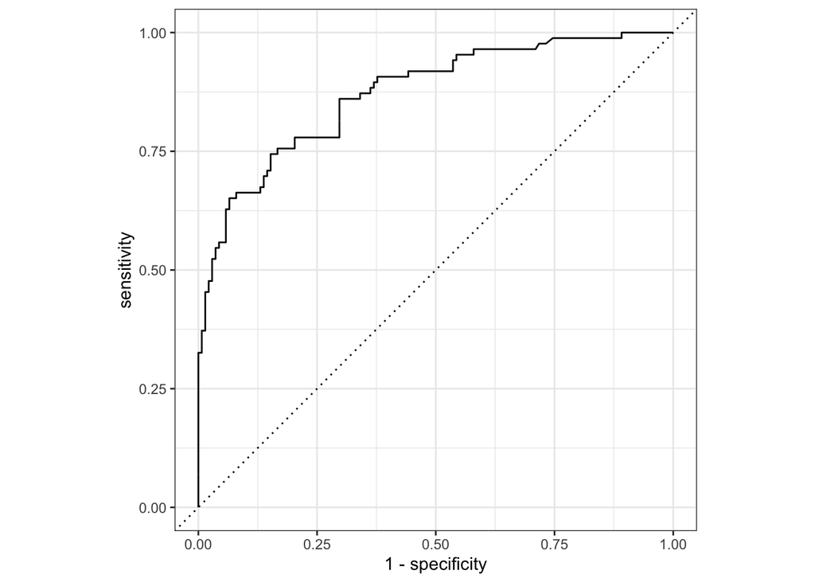

```r
titanic_log_test_results %>%
  roc_curve(survived, .pred_Yes) %>%
  autoplot()
```

```r
titanic_log_test_results %>%
  roc_auc(survived, .pred_Yes)
```

```
## # A tibble: 1 × 3
##   .metric .estimator .estimate
##   <chr>   <chr>          <dbl>
## 1 roc_auc binary         0.871
```

The area under the ROC curve is 0.87, which is measuring how well the model successfully discriminates between classes. In my opinion, overall, the model performed pretty well with an final accuracy of about 80% on the testing data. The accuracy on the training data was about 81%, so as we can see, the model performed very similarly for both the training and testing data. The 1% of difference in accuracy can be intuitively understood due to the fact that the model was tested on different data than it was trained on.